# Diversity tutorial多样性分析教程

Yong-Xin Liu(刘永鑫), Tao Wen(文涛)

2021-03-14

如果你使用本代码，请引用：

Yong-Xin Liu, Yuan Qin, Tong Chen, Meiping Lu, Xubo Qian, Xiaoxuan Guo & Yang Bai. (2021). A practical guide to amplicon and metagenomic analysis of microbiome data. Protein & Cell 12, doi: https://doi.org/10.1007/s13238-020-00724-8

# 简介 Introduction

## 安装 Installation

The [amplicon R package](https://github.com/microbiota) facilitates statistics and visualization of amplicon profiling data, in particular 16S and ITS alpha / beta diversity, and taxonomy composition.

```r
# 基于CRAN安装R包
p_list = c("ggplot2", "BiocManager", "devtools")
for(p in p_list){if (!requireNamespace(p)){install.packages(p)}
    library(p, character.only = TRUE, quietly = TRUE, warn.conflicts = FALSE)}

# 基于Bioconductor安装R包
if (!requireNamespace("ggtree", quietly = TRUE))
    BiocManager::install("ggtree")

# 基于github安装，检测没有则安装
library(devtools)
if(!requireNamespace("amplicon", quietly = TRUE))
  install_github("microbiota/amplicon")

# 加载R包 Load the package
suppressWarnings(suppressMessages(library(amplicon)))
```

## 实验设计 Design/Metadata

设置基本参数：读取实验设计、设置分组列名、图片宽高

Setting the basic parameter

```r
# Data reading
metadata = read.table("metadata.txt", header=T, row.names=1, sep="\t", comment.char="", stringsAsFactors = F)
head(metadata, n = 3)
```

```
#>     Group      Date      Site        CRA       CRR BarcodeSequence
#> KO1    KO 2017/6/30  Chaoyang CRA002352  CRR117575      ACGCTCGACA
#> KO2    KO 2017/6/30  Chaoyang CRA002352  CRR117576      ATCAGACACG
#> KO3    KO  2017/7/2 Changping  CRA002352 CRR117577      ATATCGCGAG
#>     LinkerPrimerSequence      ReversePrimer Batch              Species
#> KO1  AACMGGATTAGATACCCKG ACGTCATCCCCACCTTCC     1 Arabidopsis thaliana
#> KO2  AACMGGATTAGATACCCKG ACGTCATCCCCACCTTCC     1 Arabidopsis thaliana
#> KO3  AACMGGATTAGATACCCKG ACGTCATCCCCACCTTCC     1 Arabidopsis thaliana
#>     Sequencing  Platform latitude_longitude           Description
#> KO1   Novagene HiSeq2500   39.59 N 116.22 E Knock-out replicate 1
#> KO2   Novagene HiSeq2500   39.59 N 116.22 E Knock-out replicate 2
#> KO3   Novagene HiSeq2500   40.10 N 116.42 E Knock-out replicate 3
```

```r
# colnames of group ID in metadata
# 设置实验分组列名
group = "Group"
# Output figure width and height
# Letter纸图片尺寸为单栏89 mm，双栏183 mm，页面最宽为247 mm
# 推荐比例16：10，即半版89 mm x 56 mm; 183 mm x 114 mm
width = 89
height = 59

# 手动指定分组列和顺序，默认为字母顺序
# metadata[[group]] = factor(metadata[[group]], levels = c("WT","KO","OE"))
# 按实验设计中分组出现顺序
# metadata[[group]] = factor(metadata[[group]], levels = unique(metadata[[group]]))
```

# α多样性 Alpha diversity

## 箱线图+统计 Boxplot+Statistics

绘制主要分三步： Plotting each figure mainly include three step:

1. 读取数据并预览格式Reading data and viewing format;
2. 参数调整和绘图Paramters adjustment and plotting;
3. 保存图片Saving figure.

```r
# vegan.txt中还有6种常用α多样性，alpha.txt中有11种α多样性
alpha_div = read.table("alpha/vegan.txt", header=T, row.names=1, sep="\t", comment.char="")
head(alpha_div, n = 3)
```

```
#>     richness    chao1      ACE  shannon   simpson invsimpson
#> KO1     1207 1462.818 1473.974 5.844871 0.9895151   95.37525
#> KO2     1201 1473.502 1477.967 5.903582 0.9912497  114.28206
#> KO3     1038 1381.057 1383.316 5.559570 0.9881643   84.49029
```

```r
# capitalize
library(Hmisc)
colnames(alpha_div) = capitalize(colnames(alpha_div))
colnames(alpha_div)
```

```
#> [1] "Richness"   "Chao1"      "ACE"        "Shannon"    "Simpson"
#> [6] "Invsimpson"
```

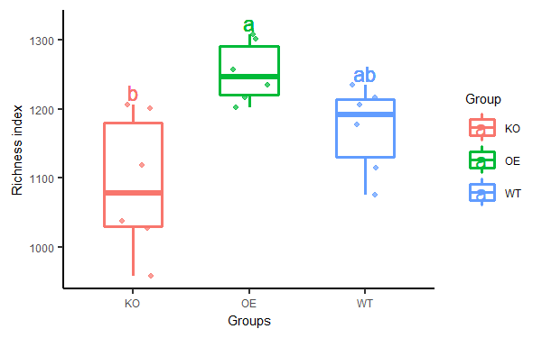

```r
# 选择指数"Richness","Chao1","ACE","Shannon","Simpson","Invsimpson"
alpha_index = "Richness"

# Plotting alpha diversity Richness boxplot and stat
(p = alpha_boxplot(alpha_div, index = alpha_index, metadata, groupID = group))
```

```r
# Saving figure
# 保存图片，大家可以修改图片名称和位置，长宽单位为毫米
ggsave(paste0("alpha/alpha_boxplot_",alpha_index,".pdf"), p, width = width, height = height, units = "mm")
# 另存图片用于后期拼图
p1 = p

# 尝试探索不同的多样性各类
colnames(alpha_div)
```

```
#> [1] "Richness"   "Chao1"      "ACE"        "Shannon"    "Simpson"
#> [6] "Invsimpson"
```

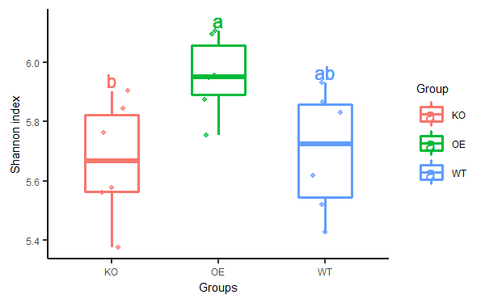

```r
alpha_boxplot(alpha_div, index = "Shannon", metadata, groupID = group)
```

```r
# 尝试不同的分组方式
colnames(metadata)
```

```
#>  [1] "Group"                "Date"                 "Site"
#>  [4] "CRA"                  "CRR"                  "BarcodeSequence"
#>  [7] "LinkerPrimerSequence" "ReversePrimer"        "Batch"
#> [10] "Species"              "Sequencing"           "Platform"
#> [13] "latitude_longitude"   "Description"
```

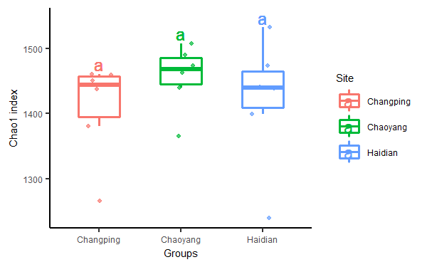

```r
alpha_boxplot(alpha_div, index = "Chao1", metadata, groupID = "Site")
```

## 稀释曲线+标准误 Rarefaction curve and standard error

```r
# 数据读取 Data reading
alpha_rare = read.table("alpha/alpha_rare.txt", header=T, row.names=1, sep="\t", comment.char="")
alpha_rare[1:3, 1:3]
```

```
#>   KO1 KO2 KO3
#> 1  33  31  36
#> 2  74  75  70
#> 3 116 123 119
```

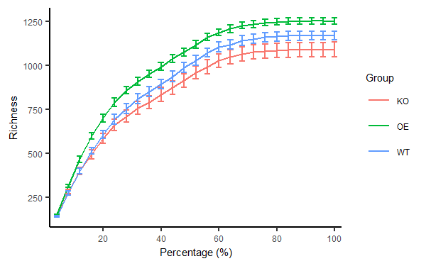

```r
# 绘制稀释曲线+标准误 Plotting alpha rarefaction curve in group mean with standard error
(p = alpha_rare_curve(alpha_rare, metadata, groupID = group))
```

```r
# 保存图片 Saving figure
ggsave("alpha/alpha_rarefaction_curve.pdf", p, width = width, height = height, units = "mm")
p2 = p
```

## 各组多样性种组比较 Venn/Upset/Sanky

命令行 sp_vennDiagram.sh 绘制维恩图

推荐使用`otu_group_exist.txt`在线 http://www.ehbio.com/ImageGP 绘制Venn/Upset/Sanky

# β多样性 Beta diversity

## 主坐标轴分析 PCoA

principal coordinate analysis (PCoA)

```r
# 主坐标轴分析，可选距离矩阵bray_curtis、unifrac、unifrac_binary、jaccard、manhatten、euclidean
# 设置距离矩阵类似，常用bray_curtis或unifrac
distance_type = "bray_curtis"
# Data reading
distance_mat = read.table(paste0("beta/",distance_type,".txt"), header=T, row.names=1, sep="\t", comment.char="")
distance_mat[1:3, 1:3]
```

```
#>       KO1   KO2   KO3
#> KO1 0.000 0.300 0.342
#> KO2 0.300 0.000 0.374
#> KO3 0.342 0.374 0.000
```

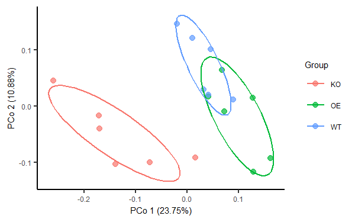

```r
# Plotting Constrained PCoA based on distance matrix
(p = beta_pcoa(distance_mat, metadata, groupID = group))
```

```r
# Saving figure
ggsave(paste0("beta/",distance_type,".pcoa.pdf"), p, width = width, height = height, units = "mm")
p3 = p

# statistic each pairwise by adonis
beta_pcoa_stat(distance_mat, metadata, groupID = group)
```

```
#>   sampA sampB
#> 1    KO    OE
#>   sampA sampB
#> 1    KO    WT
#>   sampA sampB
#> 1    OE    WT
```

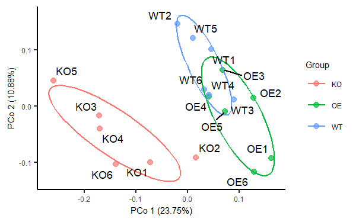

```r
# 结果文件默认见beta_pcoa_stat.txt

# 展示样本标签 Display sample label
(p = beta_pcoa(distance_mat, metadata, groupID = group, label = T))
```

```r
# 保存图片放大
ggsave(paste0("beta/",distance_type,".pcoa.label.pdf"), p, width = width*1.2, height = height*1.2, units = "mm")
```

## 有监督PCoA/CCA

Constrained PCoA

要求至少分组数量 >= 3时才可用，否则请跳过此步分析

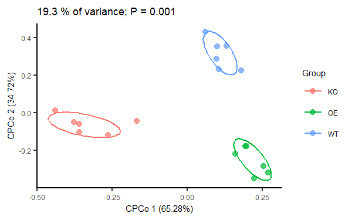

```r
# Plotting Constrained PCoA
(p = beta_cpcoa_dis(distance_mat, metadata, groupID = group))
```

```r
# Saving figure
ggsave(paste0("beta/",distance_type,".cpcoa.pdf"), p, width = width, height = height, units = "mm")
p4 = p
```

# 物种组成 Taxonomy stackplot

分别绘制样本和组均值的物种组成

Samples and groups

```r
# 设置分析级别 门p、纲c、目o、科f、属g
tax_level = "p"
# Data reading
tax_phylum = read.table(paste0("tax/sum_", tax_level, ".txt"), header=T, row.names=1, sep="\t", comment.char="")
tax_phylum[1:3, 1:3]
```

```
#>                  KO1   KO2  KO3
#> Proteobacteria 63.80 49.50 60.4
#> Actinobacteria 26.70 39.90 27.9
#> Unassigned      3.78  4.38  2.4
```

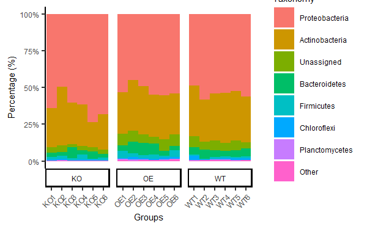

```r
# Plotting samples taxonomy composition
(p = tax_stackplot(tax_phylum, metadata, topN = 8, groupID = group, style = "sample", sorted = "abundance"))
```

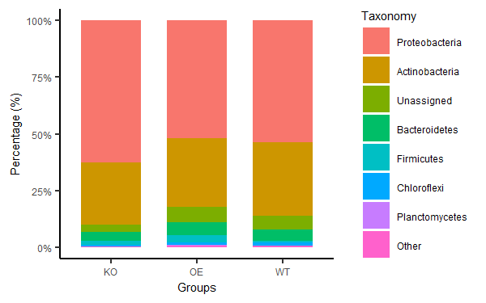

```r
p5 =p
ggsave(paste0("tax/", tax_level,"_sample.pdf"), p, width = width, height = height, units = "mm")

# Plotting groups taxonomy composition
(p = tax_stackplot(tax_phylum, metadata, topN = 8, groupID = group, style = "group", sorted = "abundance"))
```

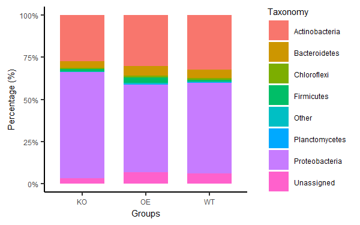

```r
p6 = p
ggsave(paste0("tax/", tax_level,"_group.pdf"), p, width = width, height = height, units = "mm")

# 按字母顺序排列
(p = tax_stackplot(tax_phylum, metadata, topN = 8, groupID = group, style = "group", sorted = "alphabet"))
```

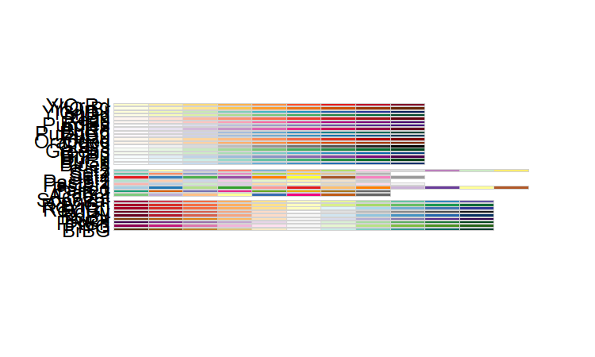

```r
# 修改配色方案
library(RColorBrewer)
display.brewer.all()
```

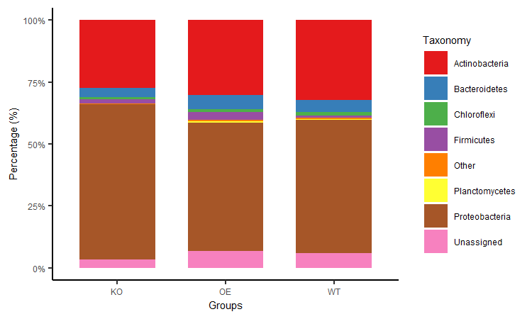

```r
(p = p + scale_fill_brewer(palette = "Set1"))
```

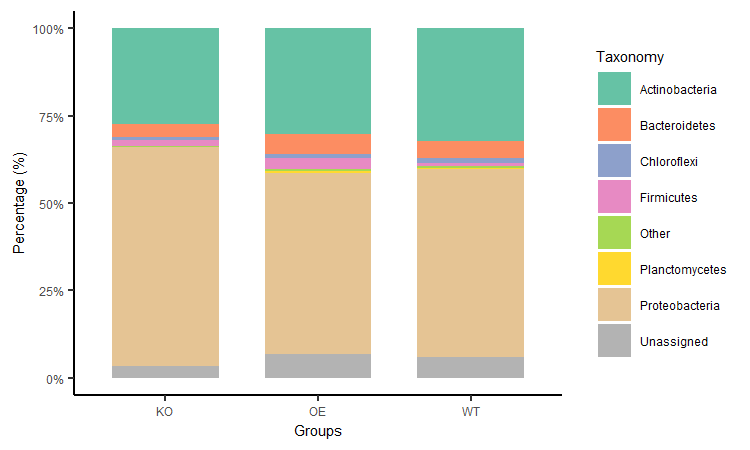

```r
ggsave(paste0("tax/", tax_level,"_group.Set1.pdf"), p, width = width, height = height, units = "mm")
(p = p + scale_fill_brewer(palette = "Set2"))
```

```r
ggsave(paste0("tax/", tax_level,"_group.Set2.pdf"), p, width = width, height = height, units = "mm")
```

## 弦图 circlize plot

```r
# 输出结果有当前目录下默认参数的弦图circlize.pdf，每次颜色随机
# 指定颜色和图例的弦图circlize_legend.pdf
tax_circlize(tax_phylum, metadata, topN = 5, groupID = group)
```

```r
# 查看结果不美观，尝试不同水平，如以纲为例
tax_class = read.table(paste0("tax/sum_c.txt"), header=T, row.names=1, sep="\t", comment.char="")
tax_circlize(tax_class, metadata, topN = 8, groupID = group)
```

## 树图treemap

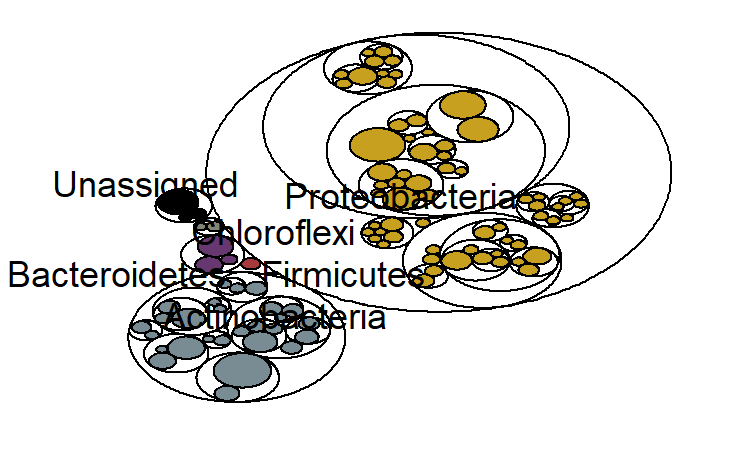

```r
# 读取特征表OTU/ASV
otutab = as.matrix(read.delim("../result/otutab.txt",row.names = 1))
# head(otutab)
# 读取7级物种注释
taxonomy = as.matrix(read.delim("../result/taxonomy.txt",row.names = 1))
# head(taxonomy)
# 指定显示的特征数量，与图中最低级别球形数量相同
topN = 100

# 数据转换为maptree格式
mapdata = format2maptree(otutab, taxonomy, topN)
#按照平均丰度修改大小和按照门水平上色颜色
mapadd = tax_maptree(mapdata)
(p = mapadd[[1]])
```

```r
ggsave("tax_maptree.pdf", p, width = 183, height = 118, units = "mm" )
```

# 排版 Combo plots

组合多个子图为发表格式

Combo plots to published-ready figure

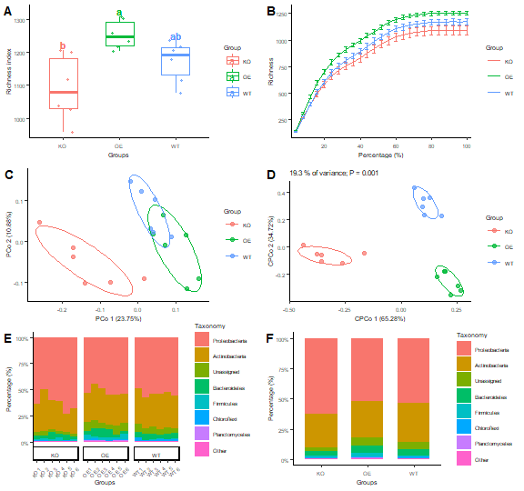

```r
library(cowplot)
(p0 = plot_grid(p1, p2, p3, p4, p5, p6, labels = c("A", "B", "C", "D", "E", "F"), ncol = 2))
```

```r
ggsave("diversity.pdf", p0, width = width * 2, height = height * 3, units = "mm")
```

使用此脚本，请引用下文：

If used this script, please cited:

**Yong-Xin Liu**, Yuan Qin, **Tong Chen**, et. al. A practical guide to amplicon and metagenomic analysis of microbiome data. **Protein Cell**, doi: 10.1007/s13238-020-00724-8 (2020).

Copyright 2016-2021 Yong-Xin Liu metagenome@126.com